# Heart Disease Project

**Import Libraries**

```python
import pandas as pd
import numpy as np
import matplotlib.pyplot as plt
import seaborn as sns
%matplotlib inline
```

**1. Load Data**

```python
mydata = pd.read_csv("Heart Disease data.csv")
```

**2. Display top 5 rows**

```python
mydata.head()
```

|  | age | sex | cp | trestbps | chol | fbs | restecg | thalach | exang | oldpeak | slope | ca | thal | target |
| --- | --- | --- | --- | --- | --- | --- | --- | --- | --- | --- | --- | --- | --- | --- |
| 0 | 52 | 1 | 0 | 125 | 212 | 0 | 1 | 168 | 0 | 1.0 | 2 | 2 | 3 | 0 |
| 1 | 53 | 1 | 0 | 140 | 203 | 1 | 0 | 155 | 1 | 3.1 | 0 | 0 | 3 | 0 |
| 2 | 70 | 1 | 0 | 145 | 174 | 0 | 1 | 125 | 1 | 2.6 | 0 | 0 | 3 | 0 |
| 3 | 61 | 1 | 0 | 148 | 203 | 0 | 1 | 161 | 0 | 0.0 | 2 | 1 | 3 | 0 |
| 4 | 62 | 0 | 0 | 138 | 294 | 1 | 1 | 106 | 0 | 1.9 | 1 | 3 | 2 | 0 |

**- Age**

**- Sex**

**- Chest Pain (4 values)**

```
> Value 0 - typical angina

> Value 1 - atypical angina

> Value 2 - non_anginal pain

> Value 3 - asymptomatic
```

**- trestbps : Testing blood pressure in mm hg**

**- chol : serum cholestrol in mg/dl**

**- fbs : Fasting blood pressure > 120 mg/dl (1 = True, 0 = False)**

**- restecg : resting electrocardiographic results**

```
          > value 0 = Normal

          > value 1 = having ST-T wave abnormality

          > value 2 = showing probable or definite left ventricular hypertrophy by Estes' criteria
```

**- thalach : maximum heartrate achieved**

**- exang : exercise induced angina (0 = No, 1 = Yes)**

**- oldpeak : ST depression induced by exercise related to rest**

**- slope : slope of the peak exercise ST segment**

[output not shown]

**- ca : no. of major vessels(0-3) colored by flourosopy**

**- target : 0 = less chance of heart attach, 1 = more chance of heart attach**

**3. Display last 5 rows**

```python
mydata.tail()
```

|  | age | sex | cp | trestbps | chol | fbs | restecg | thalach | exang | oldpeak | slope | ca | thal | target |
| --- | --- | --- | --- | --- | --- | --- | --- | --- | --- | --- | --- | --- | --- | --- |
| 1020 | 59 | 1 | 1 | 140 | 221 | 0 | 1 | 164 | 1 | 0.0 | 2 | 0 | 2 | 1 |
| 1021 | 60 | 1 | 0 | 125 | 258 | 0 | 0 | 141 | 1 | 2.8 | 1 | 1 | 3 | 0 |
| 1022 | 47 | 1 | 0 | 110 | 275 | 0 | 0 | 118 | 1 | 1.0 | 1 | 1 | 2 | 0 |
| 1023 | 50 | 0 | 0 | 110 | 254 | 0 | 0 | 159 | 0 | 0.0 | 2 | 0 | 2 | 1 |
| 1024 | 54 | 1 | 0 | 120 | 188 | 0 | 1 | 113 | 0 | 1.4 | 1 | 1 | 3 | 0 |

**4. Find shape of dataset (No. of rows and columns)**

```python
mydata.shape
```

```
(1025, 14)
```

```python
print("Number of rows : ", mydata.shape[0])
print("Number of columns : ", mydata.shape[1])
```

```
Number of rows :  1025
Number of columns :  14
```

**5. Extract the necessary information of the dataset**

```python
mydata.info()
```

```
<class 'pandas.core.frame.DataFrame'>
RangeIndex: 1025 entries, 0 to 1024
Data columns (total 14 columns):
 #   Column    Non-Null Count  Dtype
---  ------    --------------  -----
 0   age       1025 non-null   int64
 1   sex       1025 non-null   int64
 2   cp        1025 non-null   int64
 3   trestbps  1025 non-null   int64
 4   chol      1025 non-null   int64
 5   fbs       1025 non-null   int64
 6   restecg   1025 non-null   int64
 7   thalach   1025 non-null   int64
 8   exang     1025 non-null   int64
 9   oldpeak   1025 non-null   float64
 10  slope     1025 non-null   int64
 11  ca        1025 non-null   int64
 12  thal      1025 non-null   int64
 13  target    1025 non-null   int64
dtypes: float64(1), int64(13)
memory usage: 112.2 KB
```

**6. Check null values**

```python
mydata.isnull().sum()
```

```
age         0
sex         0
cp          0
trestbps    0
chol        0
fbs         0
restecg     0
thalach     0
exang       0
oldpeak     0
slope       0
ca          0
thal        0
target      0
dtype: int64
```

**7. Check duplicates and drop them**

```python
mydata_dupp = mydata.duplicated().any()
print(mydata_dupp)
```

```
True
```

```python
finaldata = mydata.drop_duplicates()
```

```python
finaldata.shape
```

```
(302, 14)
```

**8. Overall statistics of dataset**

```python
finaldata.describe()
```

|  | age | sex | cp | trestbps | chol | fbs | restecg | thalach | exang | oldpeak | slope | ca | thal | target |
| --- | --- | --- | --- | --- | --- | --- | --- | --- | --- | --- | --- | --- | --- | --- |
| count | 302.00000 | 302.000000 | 302.000000 | 302.000000 | 302.000000 | 302.000000 | 302.000000 | 302.000000 | 302.000000 | 302.000000 | 302.000000 | 302.000000 | 302.000000 | 302.000000 |
| mean | 54.42053 | 0.682119 | 0.963576 | 131.602649 | 246.500000 | 0.149007 | 0.526490 | 149.569536 | 0.327815 | 1.043046 | 1.397351 | 0.718543 | 2.314570 | 0.543046 |
| std | 9.04797 | 0.466426 | 1.032044 | 17.563394 | 51.753489 | 0.356686 | 0.526027 | 22.903527 | 0.470196 | 1.161452 | 0.616274 | 1.006748 | 0.613026 | 0.498970 |
| min | 29.00000 | 0.000000 | 0.000000 | 94.000000 | 126.000000 | 0.000000 | 0.000000 | 71.000000 | 0.000000 | 0.000000 | 0.000000 | 0.000000 | 0.000000 | 0.000000 |
| 25% | 48.00000 | 0.000000 | 0.000000 | 120.000000 | 211.000000 | 0.000000 | 0.000000 | 133.250000 | 0.000000 | 0.000000 | 1.000000 | 0.000000 | 2.000000 | 0.000000 |
| 50% | 55.50000 | 1.000000 | 1.000000 | 130.000000 | 240.500000 | 0.000000 | 1.000000 | 152.500000 | 0.000000 | 0.800000 | 1.000000 | 0.000000 | 2.000000 | 1.000000 |
| 75% | 61.00000 | 1.000000 | 2.000000 | 140.000000 | 274.750000 | 0.000000 | 1.000000 | 166.000000 | 1.000000 | 1.600000 | 2.000000 | 1.000000 | 3.000000 | 1.000000 |
| max | 77.00000 | 1.000000 | 3.000000 | 200.000000 | 564.000000 | 1.000000 | 2.000000 | 202.000000 | 1.000000 | 6.200000 | 2.000000 | 4.000000 | 3.000000 | 1.000000 |

**9. Draw Correlation matrix**

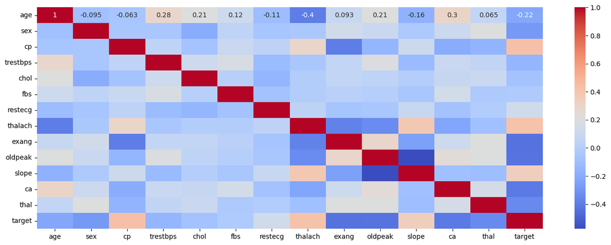

```python
plt.figure(figsize = (17,6))
sns.heatmap(finaldata.corr(), annot = True, cmap = 'coolwarm')
plt.show()
```

**10. No. of people having Heart disease and No. of people not having it**

```python
finaldata.columns
```

```
Index(['age', 'sex', 'cp', 'trestbps', 'chol', 'fbs', 'restecg', 'thalach',
       'exang', 'oldpeak', 'slope', 'ca', 'thal', 'target'],
      dtype='object')
```

```python
finaldata['target'].value_counts()
```

```
target
1    164
0    138
Name: count, dtype: int64
```

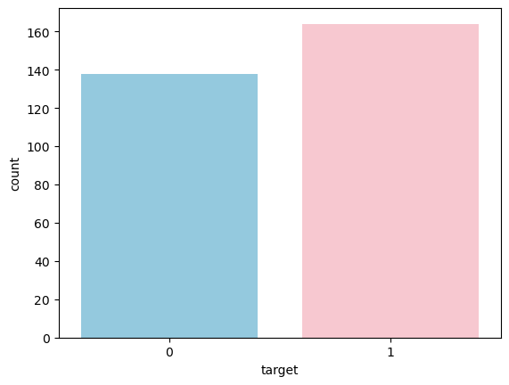

```python
pastel = ['Skyblue', 'pink']
sns.countplot(x = 'target', data = finaldata, palette = pastel)
plt.show()
```

**11. Find the count of Male and Female**

```python
finaldata.columns
```

```
Index(['age', 'sex', 'cp', 'trestbps', 'chol', 'fbs', 'restecg', 'thalach',
       'exang', 'oldpeak', 'slope', 'ca', 'thal', 'target'],
      dtype='object')
```

```python
finaldata['sex'].value_counts()
```

```
sex
1    206
0     96
Name: count, dtype: int64
```

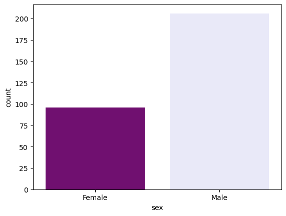

```python
pastel = ['purple', 'lavender']
sns.countplot(x = 'sex', data = finaldata, palette = pastel)
plt.xticks([0,1], ['Female', 'Male'])
plt.show()
```

**12. Gender Distribution according to target variable**

```python
finaldata.columns
```

```
Index(['age', 'sex', 'cp', 'trestbps', 'chol', 'fbs', 'restecg', 'thalach',
       'exang', 'oldpeak', 'slope', 'ca', 'thal', 'target'],
      dtype='object')
```

[figure not shown]

```python
 pastel = ['violet', 'purple']
sns.countplot(x='sex', hue = 'target', data = finaldata, palette = pastel)
plt.xticks([0,1], ['Female', 'Male'])
plt.legend(labels = ['No Disease', 'Disease'])
plt.show()
```

**13. Check age distribution in dataset**

[output not shown]

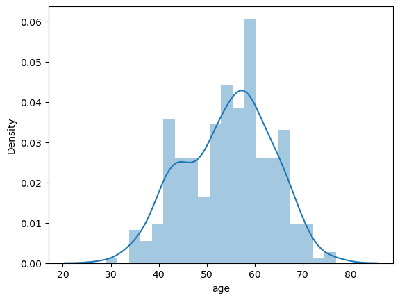

```python
sns.distplot(finaldata['age'], bins = 20)
plt.show()
```

**14. Check Chest pain type**

```
    > value 0 : typical angina
    > value 1 : atypical angina
    > value 2 : non-anginal pain
    > value 3 : asymptomatic
```

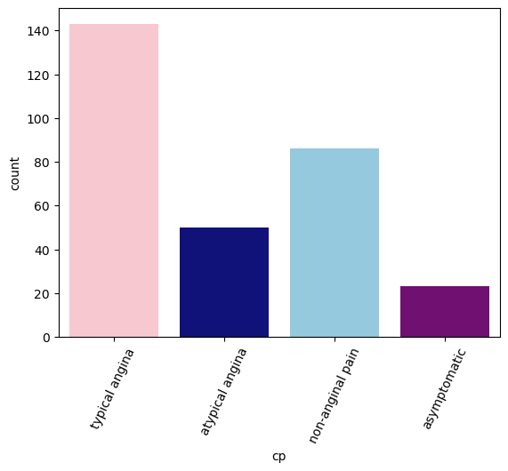

```python
pastel = ['pink', 'darkblue', 'skyblue', 'purple' ]
sns.countplot(x='cp', data = finaldata, palette = pastel)
plt.xticks([0,1,2,3], ["typical angina", 'atypical angina', 'non-anginal pain', 'asymptomatic'])
plt.xticks(rotation = 65)
plt.show()
```

**15. Show Chest pain distribution as per Target value**

```python
finaldata.columns
```

```
Index(['age', 'sex', 'cp', 'trestbps', 'chol', 'fbs', 'restecg', 'thalach',
       'exang', 'oldpeak', 'slope', 'ca', 'thal', 'target'],
      dtype='object')
```

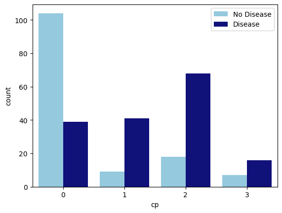

```python
pastel = ['skyblue', 'darkblue']
sns.countplot(x='cp', hue = 'target', data = finaldata, palette = pastel)
plt.legend(labels = ['No Disease', 'Disease'])
plt.show()
```

**16. Show Fasting Blood Sugar as per target value. (fbs > 120 == Diabities)**

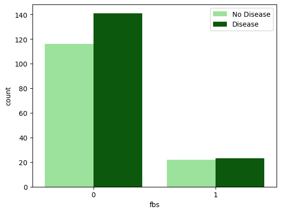

```python
pastel = ['lightgreen', 'darkgreen']
sns.countplot(x='fbs', hue = 'target', data = finaldata, palette = pastel)
plt.legend(labels = ['No Disease', 'Disease'])
plt.show()
```

**17. Check Resting Blood Pressure distribution**

```python
finaldata.columns
```

```
Index(['age', 'sex', 'cp', 'trestbps', 'chol', 'fbs', 'restecg', 'thalach',
       'exang', 'oldpeak', 'slope', 'ca', 'thal', 'target'],
      dtype='object')
```

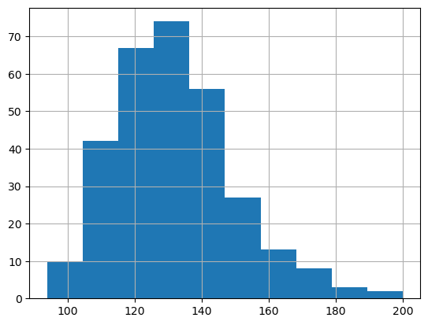

```python
finaldata['trestbps'].hist()
plt.show()
```

**18. Compare resting blood pressure with sex column**

[output not shown]

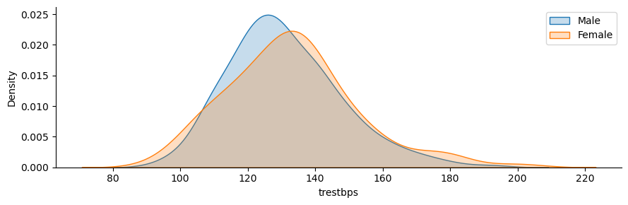

```python
fg = sns.FacetGrid(finaldata, hue = 'sex', aspect = 3)
fg.map(sns.kdeplot, 'trestbps', shade = True)
plt.legend(labels = ['Male', 'Female'])
plt.show()
```

**19. Show distribution of Serum Cholestrol - mg/dl**

```python
finaldata.columns
```

```
Index(['age', 'sex', 'cp', 'trestbps', 'chol', 'fbs', 'restecg', 'thalach',
       'exang', 'oldpeak', 'slope', 'ca', 'thal', 'target'],
      dtype='object')
```

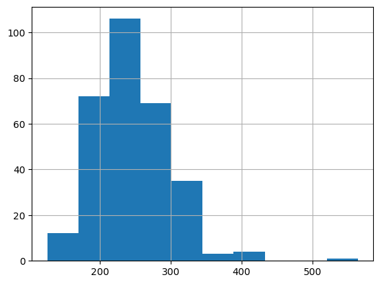

```python
finaldata['chol'].hist()
plt.show()
```

**20. Plot continuous values**

```python
finaldata.columns
```

```
Index(['age', 'sex', 'cp', 'trestbps', 'chol', 'fbs', 'restecg', 'thalach',
       'exang', 'oldpeak', 'slope', 'ca', 'thal', 'target'],
      dtype='object')
```

```python
categorical_val = []
continuous_val = []

for column in finaldata.columns:
    if finaldata[column].nunique() <=10:
        categorical_val.append(column)
    else:
        continuous_val.append(column)
```

```python
categorical_val
```

```
['sex', 'cp', 'fbs', 'restecg', 'exang', 'slope', 'ca', 'thal', 'target']
```

```python
continuous_val
```

```
['age', 'trestbps', 'chol', 'thalach', 'oldpeak']
```

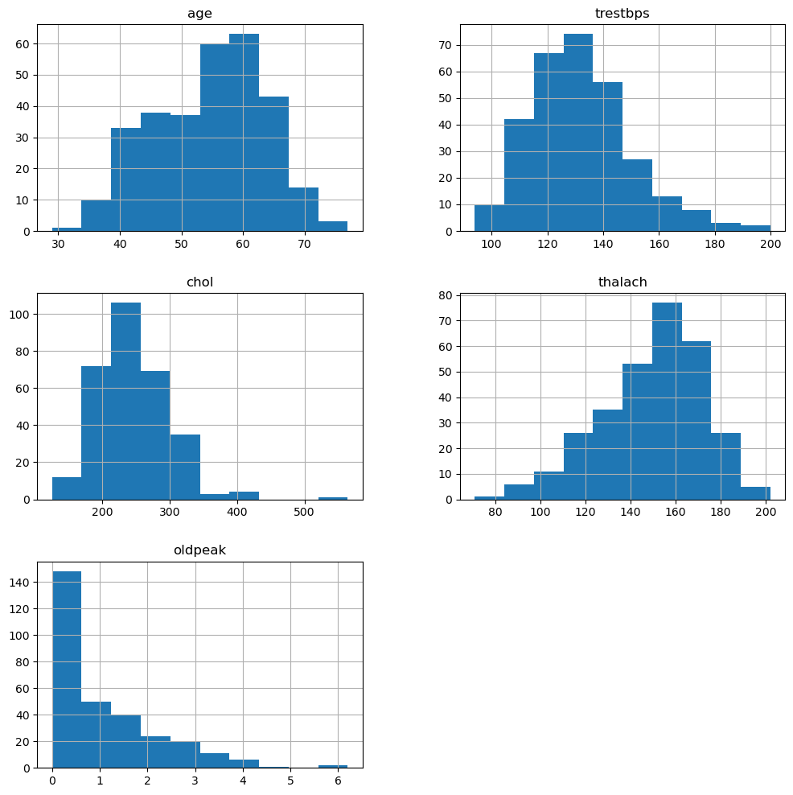

```python
finaldata.hist(continuous_val, figsize = (12,12))
plt.show()
```